# Exploratory Data Analysis for Selecting Best Publisher

Jennifer Ye

April 10th 2020

## 1 Introduction

This is a comprehensive Exploratory Data Analysis for the mobile app data. I will be using ggplot2 and the tidyverse tools to study and visualize the structures in the data.

The data comes in 4 different CSV files and includes 5 keys:  
Files:  
1) activity_data - monthly aggregated data of minutes spent on an app by a device  
2) app_publisher - publisher to app_name mapping  
3) demo_info - demographic information of a device  
4) additional_activity_data - activity data collected from additional users but without device level information  
Keys:  
app_name - App Name  
publisher - Creator/Owner of the App. A Publisher can have multiple apps  
device_id - unique id for a smartphone user  
gender_id - 1 is Male ; 2 is Female  
minutes - Time spent (in minutes) in an entire month

### 1.1 Assumption

In order to ensure the accuracy of the analysis, the following assumptions are made:  
1. The percentage of female and male in the overall population are both 50%.  
2. Both male and female have similar consumption power and merchants have the same probability of gaining profit from men and women.  
3. Consumers’ time to use APP is positively correlated with the probability of seeing an advertisement and making a purchase.

### 1.2 Load libraries and data files

```r
#install.packages("ggstatsplot")
library('ggplot2') # visualization
library('scales') # visualization
library('grid') # visualisation
library('tidyverse')# visualisation
library('tibble') # data wrangling
library('tidyr') # data wrangling
library('stringr') # string manipulation
library('forcats') # factor manipulation
library('tidytext') # text mining
library('SnowballC') # text analysis
library('wordcloud') # test visualisation
library(dplyr)
```

Import and save the datasets.

```r
#Import the data and save the datasets in a tidy way.
activity_data<-read.csv('C:/Users/Jennifer.Ye/Desktop/activity_data.csv', header = TRUE)

app_publisher<-read.csv('C:/Users/Jennifer.Ye/Desktop/app_publisher.csv', header = TRUE)

demo_info<-read.csv('C:/Users/Jennifer.Ye/Desktop/demo_info.csv', header = TRUE)

additional_activity_data<-read.csv('C:/Users/Jennifer.Ye/Desktop/additional_activity_data.csv', header = TRUE)

#look at the first six rows:
head(activity_data)
```

|  | device_id | app_name | minutes |
| --- | --- | --- | --- |
| 1 | 100 | Kindle (Mobile App) | 0.01 |
| 2 | 1987 | Pinterest (Mobile App) | 0.01 |
| 3 | 2218 | Walmart (Mobile App) | 0.01 |
| 4 | 1279 | Sam's Club Scan & Go (Mobile App) | 0.01 |
| 5 | 1355 | Google Search (Mobile App) | 0.01 |
| 6 | 2604 | Kindle (Mobile App) | 0.01 |

```r
head(app_publisher)
```

|  | app_name | Publisher |
| --- | --- | --- |
| 1 | Amazon Mobile (Mobile App) | Amazon Sites |
| 2 | Amazon Music with Prime Music (Mobile App) | Amazon Sites |
| 3 | Facebook (Mobile App) | Facebook |
| 4 | Facebook Messenger (Mobile App) | Facebook |
| 5 | Google Play (Mobile App) | Google Sites |
| 6 | Google Search (Mobile App) | Google Sites |

```r
head(demo_info)
```

|  | device_id | gender_id |
| --- | --- | --- |
| 1 | 1125 | 2 |
| 2 | 1465 | 1 |
| 3 | 940 | 2 |
| 4 | 759 | 2 |
| 5 | 1968 | 2 |
| 6 | 728 | 1 |

```r
head(additional_activity_data)
```

|  | app_name | total_devices | minutes |
| --- | --- | --- | --- |
| 1 | Kindle (Mobile App) | 379 | 43521.39 |
| 2 | Google Play (Mobile App) | 3025 | 104154.07 |
| 3 | Facebook (Mobile App) | 2672 | 2141691.64 |
| 4 | Walmart (Mobile App) | 792 | 16149.21 |
| 5 | Facebook Messenger (Mobile App) | 2722 | 1792877.26 |
| 6 | Amazon Mobile (Mobile App) | 1677 | 69338.73 |

# 2 Data Cleaning

In this part, we first tidyverse four datasets. And then we will deal with the missing data in activity_data and demo_info respectively. At last, we detect and remove outliers to improve data accurracy.

## 2.1 Tidyverse Dataset

```r
activity_data<- as.tibble(activity_data)
app_publisher<-as.tibble(app_publisher)
demo_info<-as.tibble(demo_info)
additional_activity_data<- as.tibble(additional_activity_data)
glimpse(activity_data)
```

```
## Observations: 22,440
## Variables: 3
## $ device_id <int> 100, 1987, 2218, 1279, 1355, 2604, 274, 1983, 1187, 1565,...
## $ app_name  <fct> Kindle (Mobile App), Pinterest (Mobile App), Walmart (Mob...
## $ minutes   <dbl> 0.01, 0.01, 0.01, 0.01, 0.01, 0.01, 0.01, 0.01, 0.01, 0.0...
```

```r
glimpse(app_publisher)
```

```
## Observations: 21
## Variables: 2
## $ app_name  <fct> Amazon Mobile (Mobile App), Amazon Music with Prime Music...
## $ Publisher <fct> "Amazon Sites", "Amazon Sites", "Facebook", "Facebook", "...
```

```r
glimpse(demo_info)
```

```
## Observations: 2,774
## Variables: 2
## $ device_id <int> 1125, 1465, 940, 759, 1968, 728, 145, 326, 995, 851, 2639...
## $ gender_id <int> 2, 1, 2, 2, 2, 1, 2, 2, 1, 1, 2, 2, 1, 2, 1, 1, 2, 2, 1, ...
```

```r
glimpse(additional_activity_data)
```

```
## Observations: 21
## Variables: 3
## $ app_name      <fct> Kindle (Mobile App), Google Play (Mobile App), Facebo...
## $ total_devices <int> 379, 3025, 2672, 792, 2722, 1677, 67, 309, 783, 995, ...
## $ minutes       <dbl> 43521.39, 104154.07, 2141691.64, 16149.21, 1792877.26...
```

## 2.2 Find missing values

The results below show that 748 rows of activity_data and 98 rows of demo_info contain missing data.

```r
any(is.na(activity_data)) # are there any NAs?
```

```
## [1] TRUE
```

```r
any(is.na(app_publisher)) # are there any NAs?
```

```
## [1] FALSE
```

```r
any(is.na(demo_info)) # are there any NAs?
```

```
## [1] TRUE
```

```r
any(is.na(additional_activity_data)) # are there any NAs?
```

```
## [1] FALSE
```

```r
sum(is.na(activity_data))# Count number of NAs
```

```
## [1] 748
```

```r
sum(is.na(demo_info))# Count number of NAs
```

```
## [1] 98
```

Look into these rows that contain missing data:

- For 748 out of 22440 activities (3.3%), active minutes are missing.
- For 98 out of 2774 users (3.5%), gender_id are missing.

```r
#Look into these rows that contain missing data
head(filter(activity_data, is.na(minutes)))
```

| device_id | app_name | minutes |
| --- | --- | --- |
| 1197 | YouTube (Mobile App) | NA |
| 2712 | Instagram (Mobile App) | NA |
| 442 | Walmart (Mobile App) | NA |
| 2729 | Snapchat (Mobile App) | NA |
| 1322 | Google Play (Mobile App) | NA |
| 1284 | Google Search (Mobile App) | NA |

```r
head(filter(demo_info, is.na(gender_id)))
```

| device_id | gender_id |
| --- | --- |
| 1200 | NA |
| 925 | NA |
| 1325 | NA |
| 1400 | NA |
| 350 | NA |
| 50 | NA |

## 2.3 Dealing with missing values in activity_data

By observing the dataset, we find that the average active minutes for each app is significantly different from each other and for 748 out of 22440 activities (3.3%), the active minutes are missing.  
So we choose to use the average active minute of each app replace all NA data.

```r
# group by APP name
a<-aggregate(x = activity_data$minutes,                # Specify data column
          by = list(activity_data$app_name),              # Specify group indicator
          FUN = mean) # Specify function (i.e. mean)
a
```

| Group.1 | x |
| --- | --- |
| Amazon Mobile (Mobile App) | NA |
| Amazon Music with Prime Music (Mobile App) | NA |
| Facebook (Mobile App) | NA |
| Facebook Messenger (Mobile App) | NA |
| Google Play (Mobile App) | NA |
| Google Search (Mobile App) | NA |
| GroupMe (Mobile App) | NA |
| Instagram (Mobile App) | NA |
| Kindle (Mobile App) | NA |
| Microsoft Word (Mobile App) | NA |

[output cut: 11 more lines]

We use the average active minute of each app to replace all NA data.

```r
# using dplyr library to replace NAs with the average minutes of the APP groups
activity_data%>%
     group_by(app_name) %>%
      mutate(minutes = ifelse(is.na(minutes), mean(minutes, na.rm = TRUE), minutes))->activity_data
```

Inspect if all NAs were successfully replaced.

```r
#inspect: all NAs are successfully replaced
any(is.na(activity_data)) # are there any NAs?
```

```
## [1] FALSE
```

## 2.4 Dealing with the missing values in demo_info

In demo_info, 98 out of 2774 (3.5%) users’ gender data are missing. Since the missing gender data is binomial and takes only 3.5%, we will simply remove the rows that contain missing data and analyze with the remaining 96.5% gender data.

Create subsets of data and only keep complete cases.

```r
# remove NA rows
#Create a subset of data named demo_info_removena, it only keep complete cases.
demo_info <- na.omit(demo_info)
```

## 2.5 Handling Outliers and Identify Errors

It’s important to identify outliers because they aren’t representative of the rest of the population. They also could be flat-out incorrect; the more atypical the value, the more likely it could be a mistake in the data.

Now we want to figure out if there are any suspicious values for active minutes form the active_data, including values that are way too low or way too high.

#### Steps:

- Draw a boxplot before removing outliers with ggplot2
- Eliminate all outliers using the IQR function and obtain a clean dataset
- Draw a boxplot after removing outliers with ggplot2

### 2.4.1 Create a boxplot before removing outliers.

From the graph, the outlier is so large and so different from the majority that the boxplot does not even look like a box.

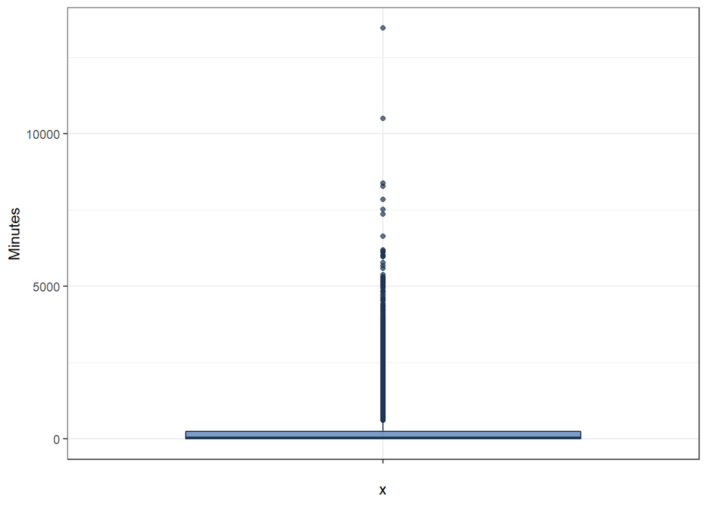

```r
# Create a boxplot.
fill <- "#4271AE"
line <- "#1F3552"
 ggplot(activity_data, aes(x = "", y = minutes)) +
        geom_boxplot(fill = fill, colour = line, alpha = 0.7) +
        scale_y_continuous(name = "Minutes") + theme_bw()
```

```r
        ggtitle("Box plot: Activity data before removing outliers")
```

```
## $title
## [1] "Box plot: Activity data before removing outliers"
##
## attr(,"class")
## [1] "labels"
```

### 2.4.2 Eliminate all outliers

I’ll be using the quantile() function to find the 25th and the 75th percentile of the dataset, and the IQR() function which elegantly gives me the difference of the 75th and 25th percentiles.  
It may be noted here that the quantile() function only takes in numerical vectors as inputs whereas activity_data is a data frame. I, therefore, specified a relevant column by adding $minutes, this passes only the “minutes” column as a numerical vector. The IQR function also requires numerical vectors and therefore arguments are passed in the same way.

```r
Q<-quantile(activity_data$minutes,probs=c(0.25,0.75),na.rm=FALSE)
iqr <- IQR(activity_data$minutes)
up <-  Q[2]+1.5*iqr # Upper Range
low<- Q[1]-1.5*iqr # Lower Range
activity_clean<- subset(activity_data, activity_data$minutes > (Q[1] - 1.5*iqr) & activity_data$minutes  < (Q[2]+1.5*iqr))
```

### 2.4.3 Create a boxplot after removing outliers and glimpse the clean activity dataset

From the boxplots, we know that before removing outliers, the minutes range from 0 to 14000. This range is too large and some bad data may influence the accuracy. After removing outliers, we narrow down the minutes data to range (0, 600), which is significantly smaller. And we do not lose a lot of data： the remaining data counts for 85.5% of the original data.

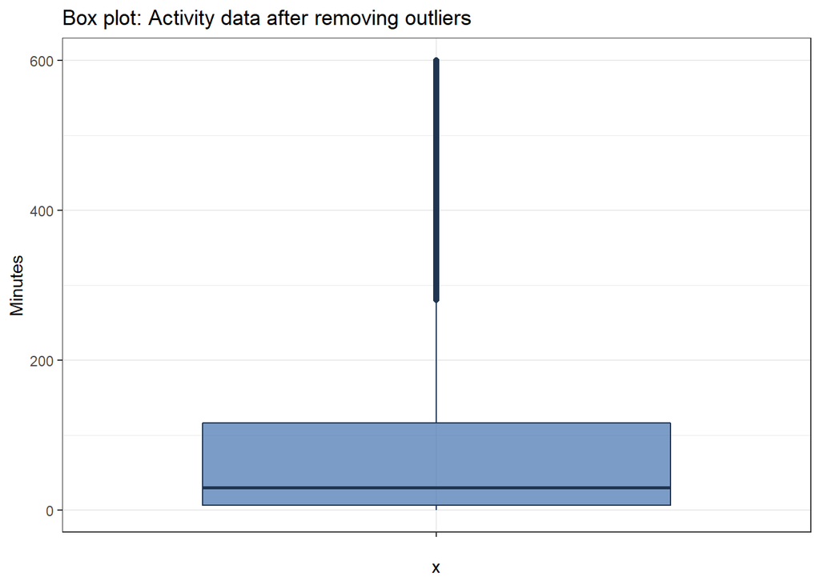

```r
fill <- "#4271AE"
line <- "#1F3552"
 ggplot(activity_clean, aes(x = "", y = minutes)) +
        geom_boxplot(fill = fill, colour = line, alpha = 0.7) +
        scale_y_continuous(name = "Minutes") + theme_bw()+
        ggtitle("Box plot: Activity data after removing outliers")
```

```r
# glimpse cleaned activity_data
glimpse(activity_clean)
```

```
## Observations: 19,201
## Variables: 3
## Groups: app_name [21]
## $ device_id <int> 100, 1987, 2218, 1279, 1355, 2604, 274, 1983, 1187, 1565,...
## $ app_name  <fct> Kindle (Mobile App), Pinterest (Mobile App), Walmart (Mob...
## $ minutes   <dbl> 0.01, 0.01, 0.01, 0.01, 0.01, 0.01, 0.01, 0.01, 0.01, 0.0...
```

The exploratory data analysis contains two parts, including: publishers analysis and demographic analysis.

In this part, we will decide the top performing publisher and top performing apps as well as customer segmentation. So the advistiser could select the best publishers with the knowledge of the customer gender distribution at these platform.

# 3 Publisher Analysis: Select Best Publishers

In this part, we provide insights on selecting the best publishers and apps for the advertisers to boost marketing compaign.

We first select three top performing publishers by analyzing the total active time, the average active time and the number of distinct users. Then we look into the detail apps of these three publishers and evaluate the performance of the apps.

## 3.1 Merge three datasets and brief view the dataset

Join table Activity_data, demo_info and app_publisher as activity_demo_publisher. Convert numerical gender_ID to “Female” and “Male”.

```r
activity_demo_info <- merge(x=activity_clean, y=demo_info,by='device_id')
activity_demo_publisher <- merge(x=activity_demo_info, y=app_publisher, by='app_name')
activity_demo_publisher$gender_id[activity_demo_publisher$gender_id == 1] <- "Male"
activity_demo_publisher$gender_id[activity_demo_publisher$gender_id == 2] <- "Female"
glimpse(activity_demo_publisher)
```

```
## Observations: 18,530
## Variables: 5
## $ app_name  <fct> Amazon Mobile (Mobile App), Amazon Mobile (Mobile App), A...
## $ device_id <int> 2476, 2189, 414, 403, 14, 501, 168, 768, 1828, 2640, 210,...
## $ minutes   <dbl> 37.87000, 1.48000, 7.17000, 52.05000, 5.00000, 16.84000, ...
## $ gender_id <chr> "Male", "Male", "Female", "Female", "Male", "Male", "Male...
## $ Publisher <fct> Amazon Sites, Amazon Sites, Amazon Sites, Amazon Sites, A...
```

Brief view: we draw a histogram and have a glimpse of the active minute. We find that the users’ active time for each publisher are significantly different.

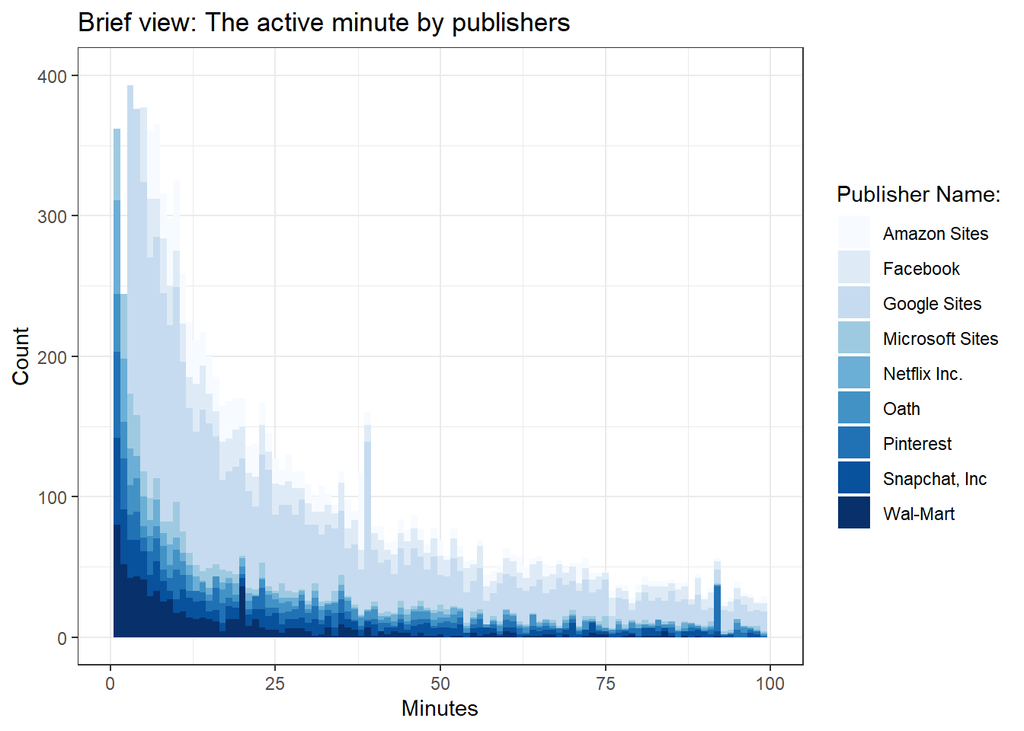

```r
activity_demo_publisher %>%
  ggplot(aes(x=minutes,fill=Publisher))+theme_bw()+geom_histogram(binwidth=1,position="stack")+xlim(c(0,100))+ylim(c(0,400))+labs(title="Brief view: The active minute by publishers", x="Minutes", y="Count")+scale_fill_brewer(palette="Blues",'Publisher Name:')
```

## 3.2 Select Top Three Publishers

### 3.2.1 Summarize Key Insights

```r
activity_demo_publisher%>%
  group_by(Publisher)%>%
  summarise(total_minutes=round(sum(minutes),digits = 2),
            average_minutes_per_activity=round(mean(minutes),digits = 2),
            number_of_activities=n(),
            distinct_users=n_distinct(device_id),
            median=median(minutes))%>%
arrange(desc(total_minutes))%>%
 arrange(desc(total_minutes)) -> Publisher_analysis
Publisher_analysis
```

| Publisher | total_minutes | average_minutes_per_activity | number_of_activities | distinct_users | median |
| --- | --- | --- | --- | --- | --- |
| Facebook | 713801.90 | 182.14 | 3919 | 2295 | 129.100 |
| Google Sites | 490010.15 | 67.23 | 7289 | 2674 | 24.500 |
| Snapchat, Inc | 138355.60 | 116.27 | 1190 | 1190 | 51.250 |
| Amazon Sites | 82081.64 | 38.23 | 2147 | 1671 | 11.660 |
| Oath | 76800.23 | 87.57 | 877 | 806 | 40.250 |
| Pinterest | 63389.35 | 71.87 | 882 | 882 | 28.125 |
| Netflix Inc. | 55436.63 | 78.52 | 706 | 706 | 16.635 |
| Microsoft Sites | 30548.17 | 43.33 | 705 | 581 | 12.120 |
| Wal-Mart | 15436.08 | 18.94 | 815 | 755 | 7.920 |

### 3.2.2 Total Active Time Analysis

In the barchart, the total active time of **Facebook** and** Google Site** are significantly higher than the average.  
Namely, the total active time of Facebook is 713801.9 minutes and is 386% the average active time; and total active time of Google Site is 490010.15 minutes and is 265% the average active time.

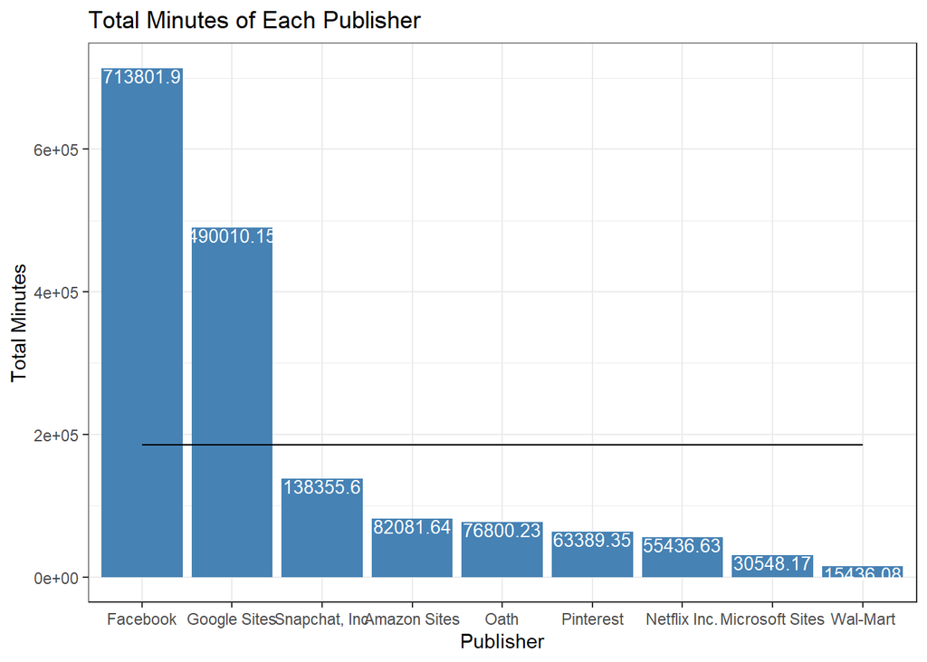

```r
# Draw Barcharts and average active time line to privide key insights of selecting publishers.
ggplot(data=Publisher_analysis, aes(x=reorder(Publisher, -total_minutes), y=total_minutes)) +
  geom_bar(stat="identity",fill="Steelblue")+theme_bw()+
  geom_line(aes(x = as.numeric(reorder(Publisher, -total_minutes)), y =  mean(total_minutes)))+
  geom_text(aes(label=total_minutes), vjust=1, color="white", size=3.5)+
  xlab("Publisher")+ylab("Total Minutes")+
  ggtitle("Total Minutes of Each Publisher")
```

```r
#Ratio
Ratio1= 713801.9/mean(Publisher_analysis$total_minutes)
Ratio2= 490010.15/mean(Publisher_analysis$total_minutes)
Ratio1
```

```
## [1] 3.856397
```

```r
Ratio2
```

```
## [1] 2.647337
```

### 3.2.3 Distinct Users Analysis

From the barchart, the **Google Sites** and **Facebook** have most distinct users and are significantly higher than the industrial average benchmark line. In detail, Google sites distinct users is 208% the industry average and Facebook is 178%.

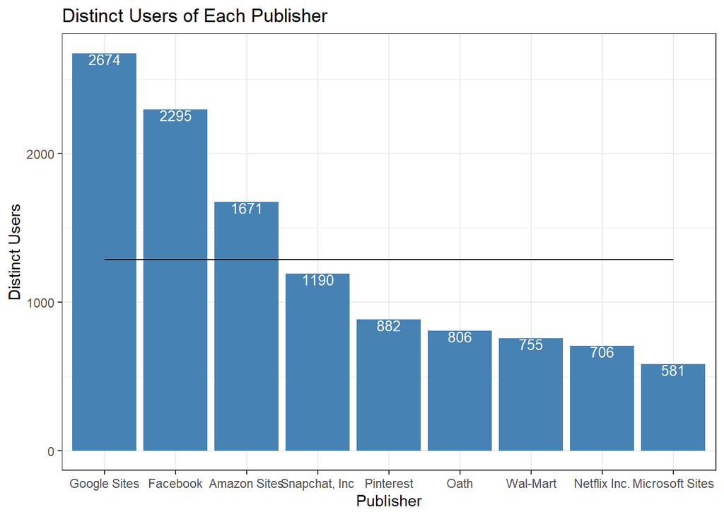

```r
# Draw Barcharts and a benchmark line of average disctince users to privide key insights of selecting publishers.

ggplot(data=Publisher_analysis,
       aes(x=reorder(Publisher, -distinct_users), y=distinct_users)) +
  geom_bar(stat="identity", fill="Steelblue")+theme_bw()+
  geom_text(aes(label=distinct_users), vjust=1, color="white",size=3.5)+
  xlab("Publisher")+ylab("Distinct Users")+ggtitle("Distinct Users of Each Publisher")+
  geom_line(aes(x = as.numeric(reorder(Publisher, -distinct_users)), y =  mean(distinct_users)))
```

```r
#Ratio
Ratio3= 2674/mean(Publisher_analysis$distinct_users)
Ratio4= 2295/mean(Publisher_analysis$distinct_users)
Ratio3
```

```
## [1] 2.081834
```

```r
Ratio4
```

```
## [1] 1.786765
```

### 3.2.4 Average Active Time Analysis

From the following barchart, the average active time of **Facebook** and **Snapchat** are significantly higher than industry average. Namely, the average active time of Facebook is 182 minutes – 233% of the industry average and the average active time of Snapchat is 116 minutes, which is 149% the industry average.

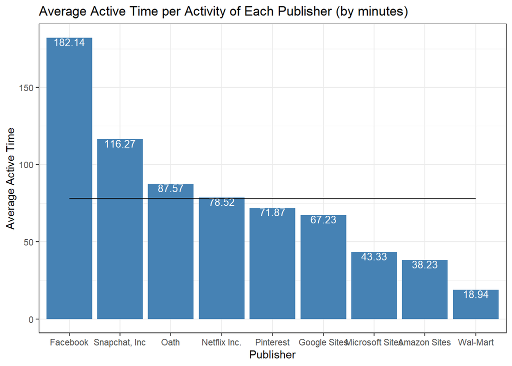

```r
# Draw Barcharts and a benchmark line of average active time to privide key insights of selecting publishers.
ggplot(data=Publisher_analysis,
       aes(x=reorder(Publisher, -average_minutes_per_activity), y=average_minutes_per_activity)) +
  geom_bar(stat="identity", fill="Steelblue")+theme_bw()+
  geom_text(aes(label=average_minutes_per_activity), vjust=1, color="white",size=3.5)+
  xlab("Publisher")+ylab("Average Active Time")+
  ggtitle("Average Active Time per Activity of Each Publisher (by minutes)")+geom_line(aes(x = as.numeric(reorder(Publisher, -average_minutes_per_activity)), y =  mean(average_minutes_per_activity)))
```

```r
#Ratio
Ratio5= 182.14/mean(Publisher_analysis$average_minutes_per_activity)
Ratio6= 116.27/mean(Publisher_analysis$average_minutes_per_activity)
Ratio5
```

```
## [1] 2.328164
```

```r
Ratio6
```

```
## [1] 1.486195
```

Comprehensively considering the analysis of the above three aspects, **Facebook** is the best performing publisher with the total active time 286% higher than the industry average active time; distincter users 78% higher than the average and average active time 182 minutes – 133% higher than the average.

The second top performing publisher is **Google Site** with the total active time 165% higher than the industry average active time; distincter users 108% higher than the average and average active time 67 minutes – 14% lower than the industry average.

The third best publisher is **Snapchat**. The average active time of snapchat is 49% higher than industry average, which indicates the user’s stickness is high. And snapchat has the total active time in the third place(25% lower than industrial average) and distinct users in the fourth place(8% lower than average).

## 3.3 App Analysis of Top 3 Pubishers

Let’s first have a brief look of the total minutes of all apps. As in the barchart, the top 7 apps are the products of the top three publishers,including Facebook, Google Site, and Snapchat. We will look into the details and evaluate the performance of these 7 apps to provide further insights on selecting apps for advertisement from top three publishers.

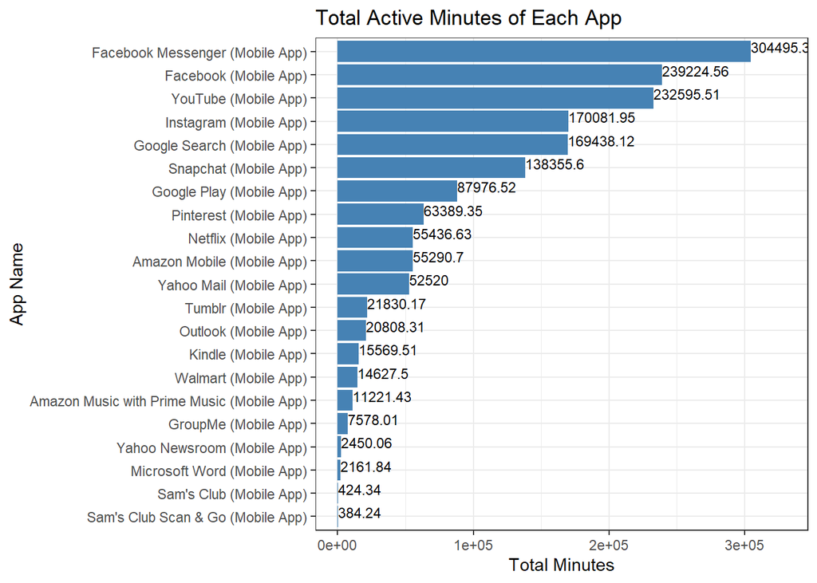

```r
activity_demo_publisher%>%
  group_by(app_name)%>%
  summarise(total_minutes=round(sum(minutes),digits = 2),
            average_minutes_per_activity=round(mean(minutes),digits = 2),
            number_of_activities=n(),
            distinct_users=n_distinct(device_id))%>%
arrange(desc(total_minutes))%>%
  arrange(desc(total_minutes))->app_glimpse
  ggplot(data=app_glimpse, aes(y=reorder(app_name, total_minutes), x=total_minutes)) +
  geom_bar(stat="identity",fill="Steelblue")+xlim(c(0,330000))+theme_bw()+
  geom_text(aes(label=total_minutes), vjust=0.1,hjust=0, color="Black", size=3)+ylab("App Name")+xlab("Total Minutes")+ggtitle("Total Active Minutes of Each App")
```

We filter out all the apps of top three performing publishers and group by app_name. Then, we glimpse the new dataset.

```r
# We filter out all the apps of top three performing publishers and group by app_name.
activity_demo_publisher%>%
  filter(Publisher=="Facebook"|Publisher=="Snapchat, Inc"|Publisher=="Google Sites")%>%
  group_by(app_name)%>%
    summarise(total_minutes=round(sum(minutes),digits = 2),
            average_minutes_per_activity=round(mean(minutes),digits = 2),
            number_of_activities=n(),
            distinct_users=n_distinct(device_id),
            median=median(minutes))%>%
arrange(desc(total_minutes))%>%
 arrange(desc(total_minutes)) -> Product_analysis
Product_analysis <- merge(x=Product_analysis, y=app_publisher, by='app_name')
# We glimpse the new dataset
  glimpse(Product_analysis)
```

```
## Observations: 7
## Variables: 7
## $ app_name                     <fct> Facebook (Mobile App), Facebook Messen...
## $ total_minutes                <dbl> 239224.56, 304495.39, 87976.52, 169438...
## $ average_minutes_per_activity <dbl> 242.62, 203.81, 33.12, 69.16, 118.19, ...
## $ number_of_activities         <int> 986, 1494, 2656, 2450, 1439, 1190, 2183
## $ distinct_users               <int> 986, 1494, 2656, 2450, 1439, 1190, 2183
## $ median                       <dbl> 217.500, 165.955, 15.905, 31.495, 52.2...
## $ Publisher                    <fct> "Facebook", "Facebook", "Google Sites"...
```

## 3.3.1 Total Active Time Analysis

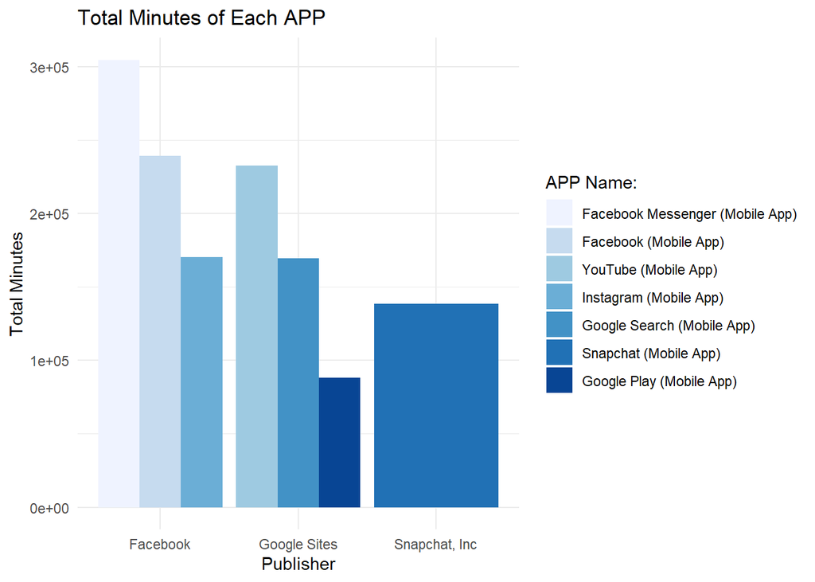

```r
# Draw Barcharts and analyze key insights.
ggplot(Product_analysis, aes(x=reorder(Publisher, -total_minutes), y=round(total_minutes,0), fill=reorder(app_name, -total_minutes))) + geom_bar(stat="identity", position=position_dodge()) + scale_fill_brewer(palette="Blues",'APP Name:')+
  theme_minimal()+xlab("Publisher")+ylab("Total Minutes")+ggtitle("Total Minutes of Each APP")
```

## 3.3.2 Distinct Users Analysis

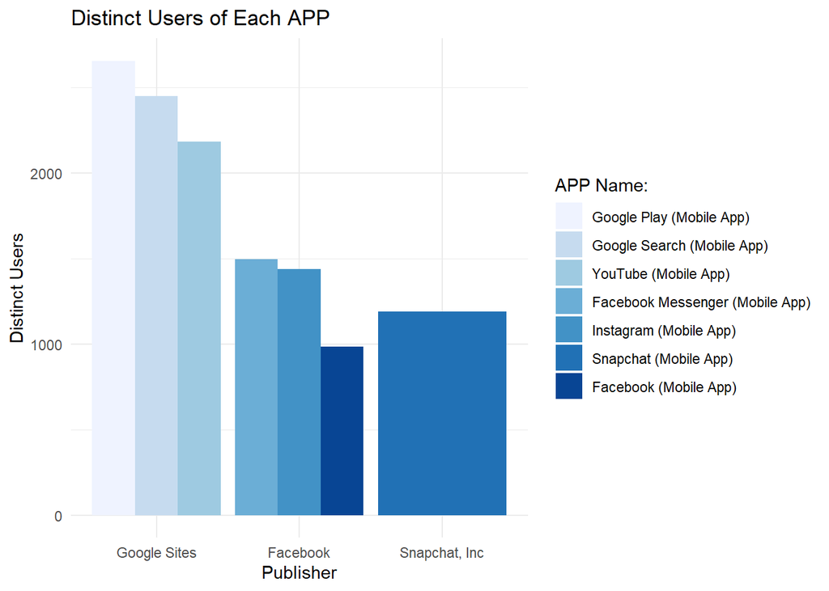

```r
ggplot(Product_analysis, aes(x=reorder(Publisher, -distinct_users), y=round(distinct_users,0), fill=reorder(app_name, -distinct_users))) + geom_bar(stat="identity", position=position_dodge()) + scale_fill_brewer(palette="Blues",'APP Name:')+
  theme_minimal()+xlab("Publisher")+ylab("Distinct Users")+ggtitle("Distinct Users of Each APP")
```

## 3.3.3 Average Active Time Analysis

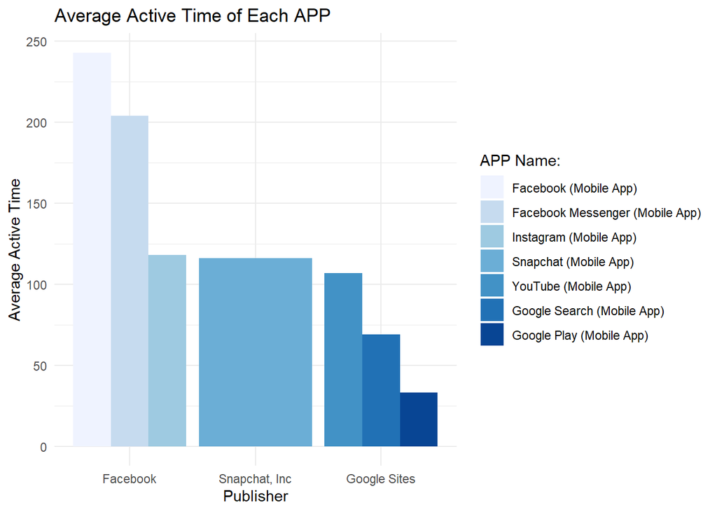

```r
# Draw Barcharts and analyze key insights.
ggplot(Product_analysis, aes(x=reorder(Publisher, -average_minutes_per_activity), y=round(average_minutes_per_activity,0), fill=reorder(app_name, -average_minutes_per_activity))) + geom_bar(stat="identity", position=position_dodge()) + scale_fill_brewer(palette="Blues",'APP Name:')+
  theme_minimal()+xlab("Publisher")+ylab("Average Active Time")+ggtitle("Average Active Time of Each APP")
```

# 4 Demographic Feature Analysis –Gender Analysis

## 4.1 Remove Demographic Bias

We discover gender bias exists in the dataset from the pie chart. The percentage of male and female should be around 50%, however, 62% data from the demo_info dataset were labeled female while 38% male.

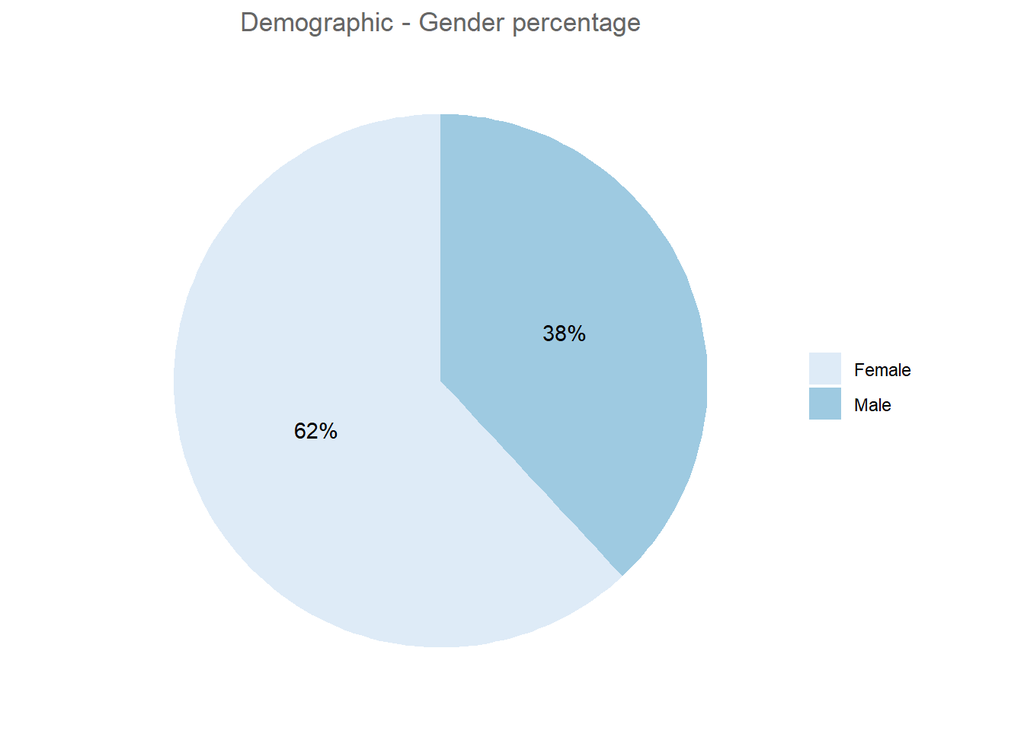

```r
activity_demo_publisher%>%
  group_by(gender_id)%>%
  summarise(distinct_users=n_distinct(device_id),
            percentage=percent(n_distinct(device_id)/2676),
            number_of_activities=n()) -> Only_Gender
# Create a basic pie chart
ggplot(Only_Gender, aes(x="", y=distinct_users, fill=gender_id)) + geom_bar(stat="identity", width=1)+ coord_polar("y", start=0) + geom_text(aes(label = paste0(percentage)), position = position_stack(vjust = 0.5)) +  scale_fill_brewer()  + labs(x = NULL, y = NULL, fill = NULL, title = "Demographic - Gender percentage") + theme_classic() + theme(axis.line = element_blank(),
          axis.text = element_blank(),
          axis.ticks = element_blank(),
          plot.title = element_text(hjust = 0.5, color = "#666666"))
```

```r
glimpse(Only_Gender)
```

```
## Observations: 2
## Variables: 4
## $ gender_id            <chr> "Female", "Male"
## $ distinct_users       <int> 1657, 1019
## $ percentage           <chr> "62%", "38%"
## $ number_of_activities <int> 11728, 6802
```

Since the demo_info dataset contains 1657 female and 1019 male, the methodology to solve the demographic bias is to **randomly select 638 female and delete the selected data**. In this way, we keep 1019 female and 1019 male in the dataset, and the percentage of both group are 50%.

```r
demo_info%>%
  filter(gender_id==2)->female
female<- female[-sample(nrow(female), 638), ] ##randomly sampling
demo_info%>%
filter(gender_id==1)->male
library(gtools)
rbind(male,female)->demo1 ## save new dataset
demo1%>%
group_by(gender_id)%>%
  summarise(distinct_users=n_distinct(device_id) ) ##the count of both gender are equal
```

| gender_id | distinct_users |
| --- | --- |
| 1 | 1019 |
| 2 | 1019 |

## 4.2 Merge new demographic dataset with activity_data, app_publisher

```r
g1 <- merge(x=activity_clean, y=demo1,by='device_id') ##merge new demographic dataset with activity_data and app_publisher
g2 <- merge(x=g1, y=app_publisher, by='app_name')
g2$gender_id[g2$gender_id == 1] <- "Male"
g2$gender_id[g2$gender_id == 2] <- "Female"
glimpse(g2)
```

```
## Observations: 14,050
## Variables: 5
## $ app_name  <fct> Amazon Mobile (Mobile App), Amazon Mobile (Mobile App), A...
## $ device_id <int> 2041, 942, 1076, 1912, 1012, 1988, 2193, 471, 531, 266, 1...
## $ minutes   <dbl> 101.14, 0.36, 166.60, 22.62, 114.57, 7.73, 23.25, 89.27, ...
## $ gender_id <chr> "Female", "Male", "Male", "Female", "Female", "Female", "...
## $ Publisher <fct> Amazon Sites, Amazon Sites, Amazon Sites, Amazon Sites, A...
```

```r
g2%>%
  group_by(Publisher,gender_id)%>%
  summarise(total_minutes=round(sum(minutes),digits = 2),
            average_minutes_per_activity=round(mean(minutes),digits = 2),
            number_of_activities=n(),
            distinct_users=n_distinct(device_id),
            median=median(minutes))%>%
arrange(desc(total_minutes))%>%
 arrange(desc(total_minutes)) -> Gender_analysis
glimpse(Gender_analysis)
```

```
## Observations: 18
## Variables: 7
## Groups: Publisher [9]
## $ Publisher                    <fct> "Facebook", "Facebook", "Google Sites"...
## $ gender_id                    <chr> "Female", "Male", "Male", "Female", "M...
## $ total_minutes                <dbl> 275895.00, 271656.88, 188753.38, 18065...
## $ average_minutes_per_activity <dbl> 186.16, 176.63, 67.92, 65.06, 138.74, ...
## $ number_of_activities         <int> 1482, 1538, 2779, 2777, 464, 452, 876,...
## $ distinct_users               <int> 884, 870, 1019, 1019, 464, 452, 657, 4...
## $ median                       <dbl> 129.750, 122.190, 23.700, 25.980, 69.1...
```

## 4.3 Gender Analysis

### 4.3.1 Total Active Time Analysis

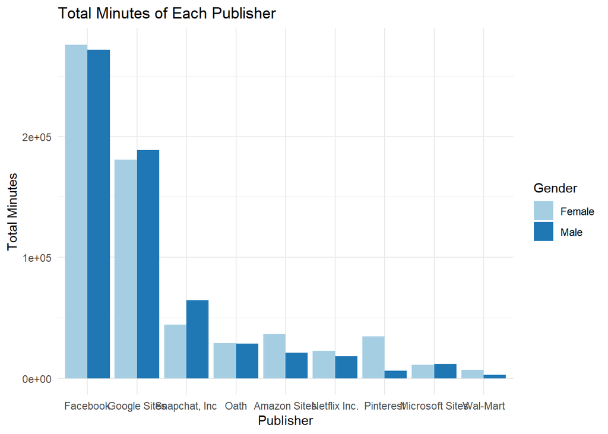

```r
ggplot(Gender_analysis, aes(x=reorder(Publisher, -total_minutes), y=round(total_minutes,0), fill=reorder(gender_id, -total_minutes))) +
   geom_bar(stat="identity", position=position_dodge()) + scale_fill_brewer(palette="Paired","Gender")+
  theme_minimal()+xlab("Publisher")+ylab("Total Minutes")+ggtitle("Total Minutes of Each Publisher")
```

### 4.3.2 Distinct User Analysis

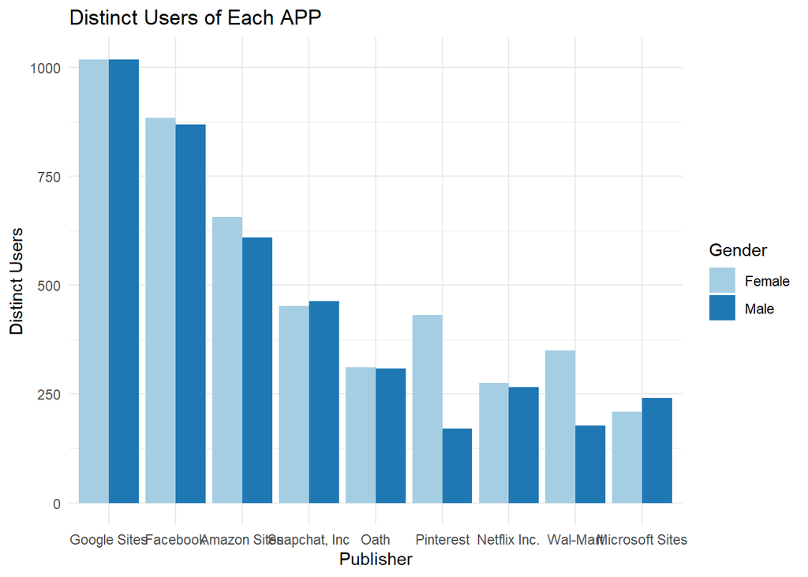

```r
ggplot(Gender_analysis, aes(x=reorder(Publisher, -distinct_users), y=round(distinct_users,0), fill=reorder(gender_id, -distinct_users))) + geom_bar(stat="identity", position=position_dodge()) + scale_fill_brewer(palette="Paired","Gender")+
  theme_minimal()+xlab("Publisher")+ylab("Distinct Users")+ggtitle("Distinct Users of Each APP")
```

### 4.3.3 Average Active Time Analysis

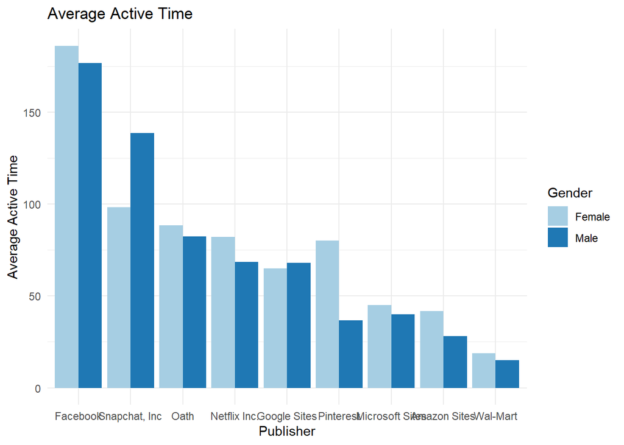

```r
ggplot(Gender_analysis, aes(x=reorder(Publisher, -average_minutes_per_activity), y=average_minutes_per_activity, fill=reorder(gender_id, -average_minutes_per_activity))) +
   geom_bar(stat="identity", position=position_dodge()) + scale_fill_brewer(palette="Paired","Gender")+
  theme_minimal()+xlab("Publisher")+ylab("Average Active Time")+ggtitle("Average Active Time")
```

**Key insights:**

- Overall, there is no big difference in the total active time, average active time and distinctive between men and women.
- Snapchat have slightly more male users.
- Pinterest have more female users.